# Reproductible Research Project 1

Hugo Dunlop

Friday, November 18, 2016

Step 1: Code to import “activity.csv” dataset. Then the str, summary, head, tail and nrow functions were used to checkthat the import was successful.

Included in this step is the use of the lubridate package to convert the date variable from a FACTOR data to a Date variable. This new variable is called DTE.

Included in this step is the creation of a weekday variable using the wday function of lubridate package, this variable is called weekday.

Missing data has not been modified.

```r
library(lubridate)
library(dplyr)
```

```r
library(ggplot2)
setwd("E:/RCourses/ReproducibleResearch/Project1")
stepdata <- read.csv("activity.csv")
summary(stepdata)
```

```
##      steps                date          interval
##  Min.   :  0.00   1/10/2012 :  288   Min.   :   0.0
##  1st Qu.:  0.00   1/11/2012 :  288   1st Qu.: 588.8
##  Median :  0.00   10/10/2012:  288   Median :1177.5
##  Mean   : 37.38   10/11/2012:  288   Mean   :1177.5
##  3rd Qu.: 12.00   11/10/2012:  288   3rd Qu.:1766.2
##  Max.   :806.00   11/11/2012:  288   Max.   :2355.0
##  NA's   :2304     (Other)   :15840
```

```r
head(stepdata)
```

```
##   steps      date interval
## 1    NA 1/10/2012        0
## 2    NA 1/10/2012        5
## 3    NA 1/10/2012       10
## 4    NA 1/10/2012       15
## 5    NA 1/10/2012       20
## 6    NA 1/10/2012       25
```

```r
str(stepdata)
```

```
## 'data.frame':    17568 obs. of  3 variables:
##  $ steps   : int  NA NA NA NA NA NA NA NA NA NA ...
##  $ date    : Factor w/ 61 levels "1/10/2012","1/11/2012",..: 1 1 1 1 1 1 1 1 1 1 ...
##  $ interval: int  0 5 10 15 20 25 30 35 40 45 ...
```

```r
stepdata$DTE <- dmy(stepdata$date)
stepdata$day <- wday(stepdata$DTE, label = TRUE)
stepdata$weekday <- ifelse(stepdata$day == "Sun" | stepdata$day == "Sat", 0,1)
table(stepdata$weekday)
```

```
##
##     0     1
##  4608 12960
```

```r
summary(stepdata)
```

```
##      steps                date          interval           DTE
##  Min.   :  0.00   1/10/2012 :  288   Min.   :   0.0   Min.   :2012-10-01
##  1st Qu.:  0.00   1/11/2012 :  288   1st Qu.: 588.8   1st Qu.:2012-10-16
##  Median :  0.00   10/10/2012:  288   Median :1177.5   Median :2012-10-31
##  Mean   : 37.38   10/11/2012:  288   Mean   :1177.5   Mean   :2012-10-31
##  3rd Qu.: 12.00   11/10/2012:  288   3rd Qu.:1766.2   3rd Qu.:2012-11-15
##  Max.   :806.00   11/11/2012:  288   Max.   :2355.0   Max.   :2012-11-30
##  NA's   :2304     (Other)   :15840
##     day          weekday
##  Sun  :2304   Min.   :0.0000
##  Mon  :2592   1st Qu.:0.0000
##  Tues :2592   Median :1.0000
##  Wed  :2592   Mean   :0.7377
##  Thurs:2592   3rd Qu.:1.0000
##  Fri  :2592   Max.   :1.0000
##  Sat  :2304
```

```r
head(stepdata)
```

```
##   steps      date interval        DTE day weekday
## 1    NA 1/10/2012        0 2012-10-01 Mon       1
## 2    NA 1/10/2012        5 2012-10-01 Mon       1
## 3    NA 1/10/2012       10 2012-10-01 Mon       1
## 4    NA 1/10/2012       15 2012-10-01 Mon       1
## 5    NA 1/10/2012       20 2012-10-01 Mon       1
## 6    NA 1/10/2012       25 2012-10-01 Mon       1
```

```r
tail(stepdata)
```

```
##       steps       date interval        DTE day weekday
## 17563    NA 30/11/2012     2330 2012-11-30 Fri       1
## 17564    NA 30/11/2012     2335 2012-11-30 Fri       1
## 17565    NA 30/11/2012     2340 2012-11-30 Fri       1
## 17566    NA 30/11/2012     2345 2012-11-30 Fri       1
## 17567    NA 30/11/2012     2350 2012-11-30 Fri       1
## 17568    NA 30/11/2012     2355 2012-11-30 Fri       1
```

```r
nrow(stepdata)
```

```
## [1] 17568
```

Step 2: The objective for this section is to generate a histogram of the total number of steps taken per day. All cases with missing values were removed.This refined version of stepdata was called stepdata1 The stepdata1 dataset was summarised using dpylr package to result in a dataset group by date with total daily steps (variable called stepsperdayRaw) for each date. The summarisedataset is called totalstepsperdayRaw. Histogram is then generated from this dataset.

```r
stepdata1 <- stepdata[complete.cases(stepdata),]
nrow(stepdata1)
```

```
## [1] 15264
```

```r
groupbyday <- group_by(stepdata1,DTE)
totalstepsperdayRaw <- summarise(groupbyday, stepsperdayRaw = sum(steps))
totalstepsperdayRaw
```

```
## Source: local data frame [53 x 2]
##
##           DTE stepsperdayRaw
## 1  2012-10-02            126
## 2  2012-10-03          11352
## 3  2012-10-04          12116
## 4  2012-10-05          13294
## 5  2012-10-06          15420
## 6  2012-10-07          11015
## 7  2012-10-09          12811
## 8  2012-10-10           9900
## 9  2012-10-11          10304
## 10 2012-10-12          17382
## ..        ...            ...
```

```r
nrow(totalstepsperdayRaw)
```

```
## [1] 53
```

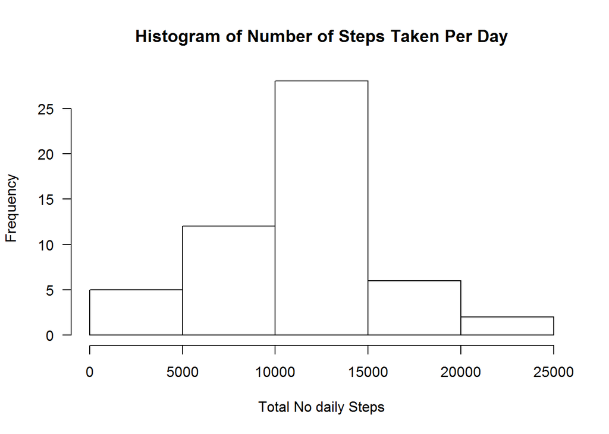

```r
hist(totalstepsperdayRaw$stepsperdayRaw,
     main="Histogram of Number of Steps Taken Per Day",
     las =1,
     xlab="Total No daily Steps")
```

Step 3: The mean and median number of steps taken per day was determined using the summarise function of dplyr using data without missing data.

```r
     meanstepsperdayRaw <- summarise(totalstepsperdayRaw, meansteps1 = mean(stepsperdayRaw))
     meanstepsperdayRaw
```

```
## Source: local data frame [1 x 1]
##
##   meansteps1
## 1   10766.19
```

```r
     medianstepsperdayRaw <- summarise(totalstepsperdayRaw, mediansteps1 = median(stepsperdayRaw))
     medianstepsperdayRaw
```

```
## Source: local data frame [1 x 1]
##
##   mediansteps1
## 1        10765
```

Step 4: The time series plot of the 5 minute intervals and the average number of steps taken for each 5-minute interval.

```r
groupbyinterval <- group_by(stepdata1,interval)
avgstepsperintervalRaw <- summarise(groupbyinterval, avgstepsperintRaw = mean(steps))
summary(avgstepsperintervalRaw)
```

```
##     interval      avgstepsperintRaw
##  Min.   :   0.0   Min.   :  0.000
##  1st Qu.: 588.8   1st Qu.:  2.486
##  Median :1177.5   Median : 34.113
##  Mean   :1177.5   Mean   : 37.383
##  3rd Qu.:1766.2   3rd Qu.: 52.835
##  Max.   :2355.0   Max.   :206.170
```

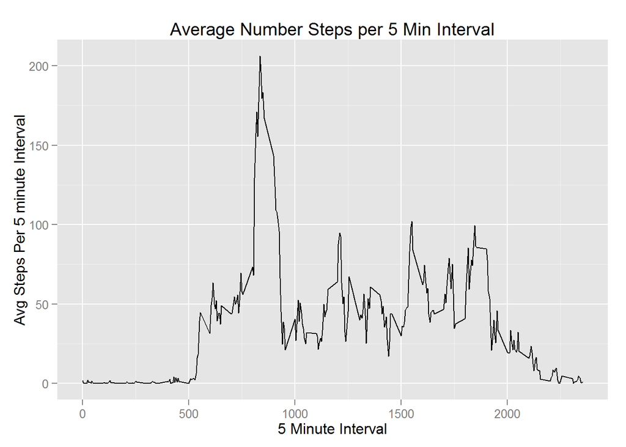

```r
stepplot <- ggplot(data = avgstepsperintervalRaw, aes(interval,avgstepsperintRaw))+
        geom_line()+
        ggtitle("Average Number Steps per 5 Min Interval")+
        xlab("5 Minute Interval") +
        ylab("Avg Steps Per 5 minute Interval")
stepplot
```

Step 5: The arrange function of dplyr was used to sort dataset by avgstepsperRaw in descending order, then use head function to determine the interval which has the highest average number of steps.

```r
sortedbystepsRaw <- arrange(avgstepsperintervalRaw,desc(avgstepsperintRaw))
maxstepint <- head(sortedbystepsRaw,1)
maxstepint$interval
```

```
## [1] 835
```

```r
maxstepint$avgstepsperintRaw
```

```
## [1] 206.1698
```

Step 6: Imputing missing step data for a 5 minute interval is done by replacing each missing step datum with the average step vale for the corresponding 5 minute interval. The raw activity.csv dataset was split into two parts: one dataset with complete data (stepdata1) and one dataset with missing step data (stepmissing).

Using the stepdata1 dataset, a dataset was created with the average number of steps for each 5 minute interval (avgstepsperintervalRaw - created at Step 4). The avgstepsperintervalRaw dataset was merged with stepmissing dataset by interval to replace the missing value with the corresponding intervals average number steps for that interval.

Then combine datasets: stepdata1 and stepmissing to make the final dataset with imputed missing data: stepdataALL. A variable was created in both stepdata1 and stepmissing datasets called “realdata” which denoted the observation real or imputed.

```r
stepdata1 <- stepdata[complete.cases(stepdata),]
stepmissing <- stepdata[!complete.cases(stepdata),]
nrow(stepdata1)
```

```
## [1] 15264
```

```r
nrow(stepmissing)
```

```
## [1] 2304
```

```r
nrow(avgstepsperintervalRaw)
```

```
## [1] 288
```

```r
head(stepmissing)
```

```
##   steps      date interval        DTE day weekday
## 1    NA 1/10/2012        0 2012-10-01 Mon       1
## 2    NA 1/10/2012        5 2012-10-01 Mon       1
## 3    NA 1/10/2012       10 2012-10-01 Mon       1
## 4    NA 1/10/2012       15 2012-10-01 Mon       1
## 5    NA 1/10/2012       20 2012-10-01 Mon       1
## 6    NA 1/10/2012       25 2012-10-01 Mon       1
```

```r
stepmissing <- left_join(stepmissing, avgstepsperintervalRaw, by = "interval")
stepmissing$steps <- stepmissing$avgstepsperintRaw
stepmissing <- select(stepmissing, steps, date, interval, DTE, day, weekday)
stepmissing$realdata <- 0
stepdata1$realdata <- 1
stepdataALL <- rbind(stepdata1,stepmissing)
str(stepdataALL)
```

```
## 'data.frame':    17568 obs. of  7 variables:
##  $ steps   : num  0 0 0 0 0 0 0 0 0 0 ...
##  $ date    : Factor w/ 61 levels "1/10/2012","1/11/2012",..: 23 23 23 23 23 23 23 23 23 23 ...
##  $ interval: int  0 5 10 15 20 25 30 35 40 45 ...
##  $ DTE     : POSIXct, format: "2012-10-02" "2012-10-02" ...
##  $ day     : Ord.factor w/ 7 levels "Sun"<"Mon"<"Tues"<..: 3 3 3 3 3 3 3 3 3 3 ...
##  $ weekday : num  1 1 1 1 1 1 1 1 1 1 ...
##  $ realdata: num  1 1 1 1 1 1 1 1 1 1 ...
```

Step 7: Histogram of the average steps per day is created using the same code as used in Step 2 but using stapdataALL dataset. In addition, the mean and median total steps per day are calculated using stepdataALL dataset.

```r
groupbydayALL <- group_by(stepdataALL,DTE)
totalstepsperdayALL <- summarise(groupbydayALL, stepsperdayALL = sum(steps))
totalstepsperdayALL
```

```
## Source: local data frame [61 x 2]
##
##           DTE stepsperdayALL
## 1  2012-10-01       10766.19
## 2  2012-10-02         126.00
## 3  2012-10-03       11352.00
## 4  2012-10-04       12116.00
## 5  2012-10-05       13294.00
## 6  2012-10-06       15420.00
## 7  2012-10-07       11015.00
## 8  2012-10-08       10766.19
## 9  2012-10-09       12811.00
## 10 2012-10-10        9900.00
## ..        ...            ...
```

```r
nrow(totalstepsperdayALL)
```

```
## [1] 61
```

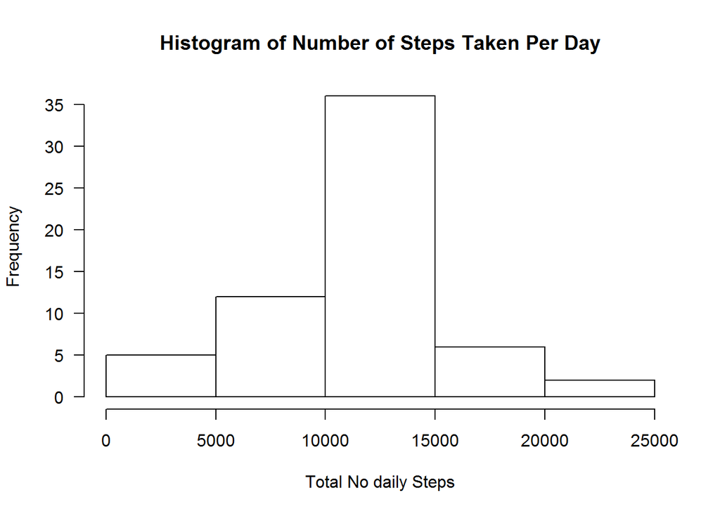

```r
hist(totalstepsperdayALL$stepsperdayALL,
     main="Histogram of Number of Steps Taken Per Day",
     las =1,
     xlab="Total No daily Steps")
```

```r
## Calculate mean and median number of steps per day
     meanstepsperdayALL <- summarise(totalstepsperdayALL, meanstepsALL = mean(stepsperdayALL))
     meanstepsperdayALL
```

```
## Source: local data frame [1 x 1]
##
##   meanstepsALL
## 1     10766.19
```

```r
     medianstepsperdayALL <- summarise(totalstepsperdayALL, medianstepsALL = median(stepsperdayALL))
     medianstepsperdayALL
```

```
## Source: local data frame [1 x 1]
##
##   medianstepsALL
## 1       10766.19
```

Step 8: Create plots of average steps per interval across weekdays and weekends using ggplot package. Dataset created first to group by interval and weekday variables

```r
groupbyintervalALL <- group_by(stepdataALL,interval,weekday)
avgstepsperintervalALL <- summarise(groupbyintervalALL, avgstepsperintALL = mean(steps))
avgstepsperintervalALL$weekday <- ifelse(avgstepsperintervalALL$weekday==0, "Weekend", "Weekday")
avgstepsperintervalALL$weekday <- factor(avgstepsperintervalALL$weekday)
summary(avgstepsperintervalALL)
```

```
##     interval         weekday    avgstepsperintALL
##  Min.   :   0.0   Weekday:288   Min.   :  0.000
##  1st Qu.: 588.8   Weekend:288   1st Qu.:  2.047
##  Median :1177.5                 Median : 28.133
##  Mean   :1177.5                 Mean   : 38.988
##  3rd Qu.:1766.2                 3rd Qu.: 61.263
##  Max.   :2355.0                 Max.   :230.378
```

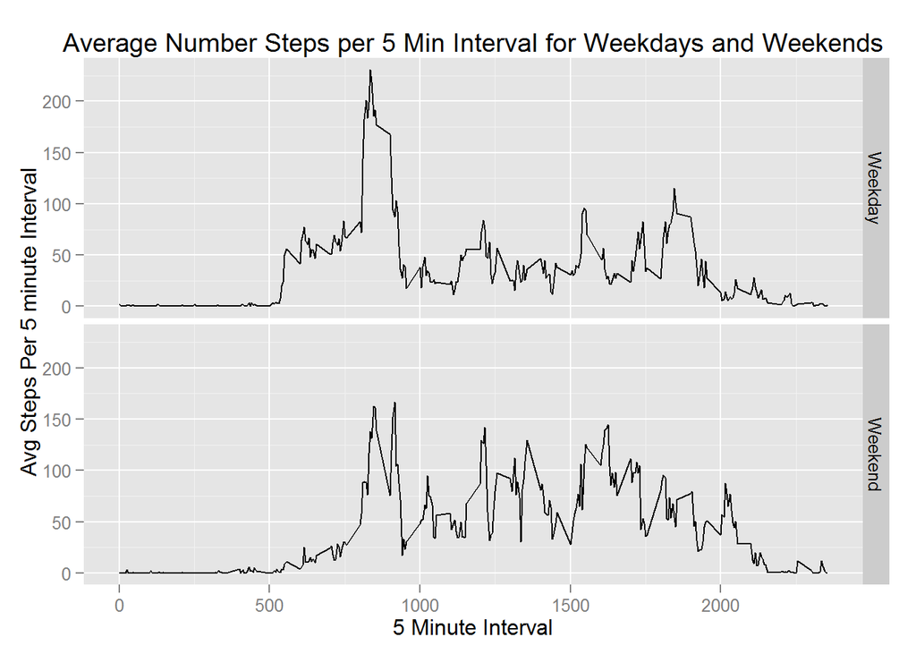

```r
stepplotWeekday <- ggplot(data = avgstepsperintervalALL, aes(interval,avgstepsperintALL))+
        geom_line()+
        facet_grid(weekday~.)+
        ggtitle("Average Number Steps per 5 Min Interval for Weekdays and Weekends")+
        xlab("5 Minute Interval") +
        ylab("Avg Steps Per 5 minute Interval")
print(stepplotWeekday)
```